# Yaw Maneuvers

During yaw maneuvers, the sideslip of the aircraft is varied using rudder action in uncoordinated turns (i.e., without compensating roll) in a manner similar to the pitch maneuver, but usually resulting in a more rapid motion. Steady wind conditions are helpful. The target (impossible without some compromise) is to fly the maneuver without roll and without significant change in altitude; this requires some small adjustment to pitch during the maneuver.

## Analysis of the yaw maneuver

The equations for the yaw maneuver are more complicated than those for the pitch maneuver, and the maneuver is very hard to fly. Ideally, the yaw maneuver should only change sideslip angle and heading without change in roll, altitude, or angle of attack, but that is impossible. It is practical, however, to minimize roll and change in altitude, while using some change in angle of attack to avoid loss of altitude, and that was how these maneuvers have been flown since DEEPWAVE. (Some from earlier projects had significant roll changes.) In the case of yaw maneuvers, the evaluation of the maneuver is based on the expectation that the horizontal wind remains constant during the maneuver. The calculation of the component of the wind lateral to the aircraft requires the measured sideslip, so evaluation of the yaw maneuver is based on consistency in that measured lateral component of the wind. However, the orientation of the aircraft and therefore the lateral component of the horizontal wind changes during the maneuver, so evaluation is instead based on determining the mean heading for the maneuver and then calculating the component of the wind normal to the mean heading direction during the maneuver.

The equations are developed as follows. If **ψ** is the mean heading, **β** the sideslip, **W** the wind speed and **δ** the wind direction, then the lateral component of the wind perpendicular to the mean heading (**W**<sub>⊥</sub>) is

[output not shown]

This is preferable to using the variable VYC in the data files because VYC is the component lateral to the aircraft so it will vary as the orientation of the aircraft changes, and if the flight direction is along the direction of the wind the lateral component varies as **W** **tanψ**<sup>′</sup> where **ψ**<sup>′</sup> is the fluctuation in the heading. The variable VYC can be corrected for this variation, but it is preferable to use **W**<sub>⊥</sub> as given by (10) because that variable should remain constant if the measurement of sideslip and other quantities entering the wind calculation are correct.

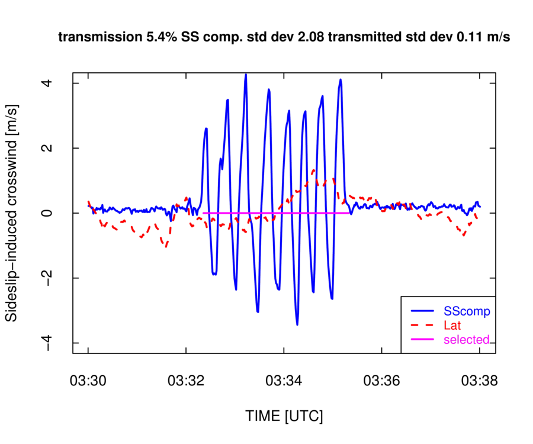

A good example of a yaw maneuver is shown in Fig. 6. Instead of SSRD, the variable plotted is SScomp=SSRD*TASX***π**/180, or the sideslip-induced crosswind component. The lateral-wind component from (10), labeled “Lat,” shows some correlation with the induced cross-wind component, with a largest-in-magnitude correlation coefficient of 0.21 for a 10-s lag and a significant correlation at zero lag also, so the wind calculation does not remove all of the induced component. As for the vertical wind, the transmitted component can be estimated from

[output not shown]

where **ρ**<sub>**max**</sub> is the maximum absolute value of the correlation coefficient for any lag, **σ**<sub>**Lat**</sub> the standard deviation in the “lateral” component, and **σ**<sub>**SScomp**</sub> the standard deviation in the induced cross-wind component. The numerator specifies the part of the standard deviation in the lateral component attributable to variations in SScomp. For this case, the transmission calculated from (11) is 5.4% of the sideslip-induced crosswind or 0.11 m/s. For this calculation, the standard deviations and correlation function are calculated only for the period of the maneuver, shown by the “selected” magenta line in the figure. The transmission indicates that only this fraction of the strong sideslip-induced crossflow appears in the measurements and the typical magnitude of the induced fluctuations is well below 10% of the induced fluctuations, so this example shows very good performance of the wind-measuring system with induced errors significantly smaller than the estimated uncertainty in the lateral component of the horizontal wind, which is 0.4 m/s.

As a test, SSRD was increased or decreased in magnitude by a few percent and the wind recalculated. This test indicated that reducing the magnitude of SSRD by a factor of 0.95 led to the minimum transmission (0.05 m/s), so this is a suggestion that the second sensitivity coefficient in use may be about 5% too large.

It is also possible to evaluate the effect of a time shift between the variable for heading (THDG) and the sideslip measurement from the radome (SSRD). Because, for negligible roll, the wind calculation depends on the sum of these two angles, any time-shift between them during the yaw maneuver will influence the transmission. When flown according to design, the roll angle should remain within about **±5**<sup>∘</sup>, so a reasonable approximation to the direction of the relative wind is **ψ +β** and the effect of a time shift can be evaluated by revising the relative-wind direction to be **ψ**<sup>′</sup>**+β** instead, where **ψ**<sup>′</sup>is the shifted heading. The ground-speed vector stays the same, so the change in the relative wind is the same as the change in the ground-relative wind, and the new wind direction is

[output not shown]

where **V** is the airspeed, **V**<sub>**x**</sub> the eastward component of the aircraft groundspeed, and **V**<sub>**y**</sub> the northward component. Then the change in direction is **δ(ψ**<sup>′</sup>**)-δ(ψ)**. Similarly, the change in wind speed can be evaluated from the two wind components in the numerator and denominator of (12). These equations can be used in place of the full calculation of the horizontal wind, to avoid the added complexity of needing all the additional variables on which that full calculation depends.

## Using the QA tool

The plot shows, as the blue line, the magnitude of the induced sideslip component of the wind. This is calculated by multiplying the sideslip angle (in radians) by the airspeed. The red line shows the lateral component of the wind, also in units of m/s. For good performance of the wind-sensing system, there should be only small variations in the red line that appear correlated with the blue line. The “transmitted component,” defined as above, will be shown in the title of the plot as both a percentage of the induced sideslip component and a standard deviation. Once the region under consideration for this calculation is restricted to the period of the maneuver, the transmitted percentage should usually be less than 10% and the transmitted standard deviation should be small in comparison to the 0.4 m/s uncertainty expected for the horizontal wind.

There are two other features of the display:

The standard deviation of the perpendicular wind during the period selected for the yaws will be compared to that in the “environment,” defined as times in the selected range for the plot but excluding the period selected for the yaws. The standard deviation during the yaws will normally not be much larger than that in the environment if the yaw maneuver does not produce significant transmission to the measured wind. This ratio is written on the plot as the “standard deviation ratio”.

There is another slider, called the “THDG delay” slider, that allows shifting the time of the heading by the specified number of milliseconds relative to other measurements, most significantly that of sideslip. This slider can be adjusted to determine if shifting the heading earlier or later will reduce the transmitted components. This shift is in addition to any shift imposed during original processing.

—- End of this Note —-